# Hugging Face Transformers Tutorial

This tutorial demonstrates the key capabilities of the Hugging Face Transformers library, covering everything from simple text classification to advanced model fine-tuning and deployment. We'll explore 5 main sections:

1. **Text Classification with Pipelines** - Quick and easy sentiment analysis
2. **Direct Model Usage** - More control over tokenization and models
3. **Text Generation** - Creative AI text completion
4. **Image Segmentation** - Computer vision with semantic segmentation
5. **Model Fine-tuning & Hub Upload** - Complete ML workflow from training to sharing

Let's get started!

## Section 1: Text Classification with Pipelines

The easiest way to get started with Hugging Face is using **pipelines**. Pipelines provide a high-level interface that abstracts away the complexity of tokenization, model inference, and post-processing.

In this section, we'll use a pre-trained multilingual sentiment analysis model to classify text as positive or negative. The pipeline automatically handles:

- Text tokenization
- Model inference
- Output formatting

This is perfect for quick prototyping and getting immediate results!

```python
from rich import print
from transformers import pipeline
classifier = pipeline("text-classification",model="tabularisai/multilingual-sentiment-analysis")
```

```
Device set to use mps:0
```

```python
result=classifier("I am happy")
```

```python
print(result)
```

```
[{'label': 'Positive', 'score': 0.43181440234184265}]
```

## Section 2: Direct Model Usage

While pipelines are convenient, sometimes you need more control over the process. In this section, we'll show how to use the tokenizer and model directly.

This approach gives you:

- **Fine-grained control** over tokenization parameters
- **Access to raw model outputs** (logits, probabilities)
- **Better understanding** of what happens under the hood
- **Flexibility** to customize preprocessing and postprocessing

Let's see how to achieve the same sentiment analysis using direct model access:

```python
from transformers import AutoTokenizer, AutoModelForSequenceClassification, pipeline
tokenizer = AutoTokenizer.from_pretrained("tabularisai/multilingual-sentiment-analysis")
model = AutoModelForSequenceClassification.from_pretrained("tabularisai/multilingual-sentiment-analysis")
classifier = pipeline("text-classification", model = model, tokenizer = tokenizer)
result = classifier("I absolutely loved the new restaurant - the food was amazing and the service was excellent!")
print(result)
```

```
Device set to use mps:0
```

```
[{'label': 'Very Positive', 'score': 0.5141021013259888}]
```

## Section 3: Text Generation

Now let's explore the creative side of AI with **text generation**! This section demonstrates how to use pre-trained language models to complete text prompts.

Text generation models can:

- Complete sentences and paragraphs
- Generate creative content
- Help with writing tasks
- Provide contextual continuations

We'll use the default text generation pipeline which typically uses GPT-2 or similar models:

```python
classifier = pipeline("text-generation")
result = classifier("I went to the mall today because")
print(result)
```

```
No model was supplied, defaulted to openai-community/gpt2 and revision 607a30d (https://huggingface.co/openai-community/gpt2).
Using a pipeline without specifying a model name and revision in production is not recommended.
Device set to use mps:0
Device set to use mps:0
Setting `pad_token_id` to `eos_token_id`:50256 for open-end generation.
Setting `pad_token_id` to `eos_token_id`:50256 for open-end generation.
```

```
[
    {
        'generated_text': "I went to the mall today because I was so excited to see what was on the menu. I have a
nice friend that worked for me and she said she saw this line. It was pretty awesome. She said it was a good way to
start your day. I'm not a huge fan of the line and my friends were super helpful with directions. I have to say
though, it was a great experience. I will definitely be back.\n\nI can't say enough good things about this place.
It is definitely worth your time and money. It's got a lot of great food and a very laid back atmosphere. I love
the smell and the atmosphere. It's also a great place to get a sandwich, drink beer, or just have a drink. Great
place to get some fresh air, and a great place to spend some time with your family.\n\nI went here for lunch at the
mall and it was the best kind of lunch I've had. It was a great option to get a good amount of quality food to go
to. The menu is a little pricey but it was worth it. The customer service was excellent and we got the right amount
of food. We could not wait to get a slice of the pizza and the chips. I am a big fan of that pizza."
    }
]
```

## Section 4: Image Segmentation

Moving beyond text, let's explore **computer vision** with semantic segmentation! This section demonstrates how to use vision transformers for segmenting different parts of an image.

We'll use a specialized Segformer model that can identify different elements in images:

- **Skin segmentation** - Identify skin regions
- **Hair segmentation** - Detect hair areas
- **Clothing segmentation** - Recognize clothing items

This model is particularly useful for fashion, beauty, and augmented reality applications. Let's see how to segment hair from an image:

```python
import cv2
import numpy as np
from transformers import AutoImageProcessor, SegformerForSemanticSegmentation
import torch

# Load the processor and model
processor = AutoImageProcessor.from_pretrained("isjackwild/segformer-b0-finetuned-segments-skin-hair-clothing")
model = SegformerForSemanticSegmentation.from_pretrained("isjackwild/segformer-b0-finetuned-segments-skin-hair-clothing")
```

### Image Processing and Visualization

Now let's process the image through our segmentation model and visualize the results. The code below:

1. **Loads and preprocesses** the input image
2. **Runs inference** to get segmentation predictions
3. **Extracts regions**
4. **Creates a visual overlay** to highlight detected areas
5. **Displays results** side-by-side for comparison

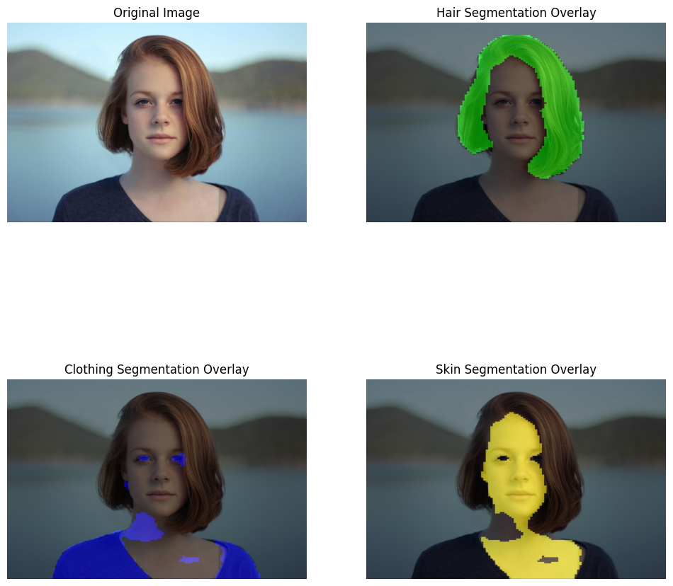

```python
import matplotlib.pyplot as plt
# Load an input image
image_path = "img.jpg" # Replace with your image path
original_image = cv2.imread(image_path)
original_image = cv2.cvtColor(original_image, cv2.COLOR_BGR2RGB)  # Convert BGR to RGB for consistency

# Preprocess the image
inputs = processor(images=original_image, return_tensors="pt")

# Perform inference
with torch.no_grad():
    outputs = model(**inputs)

# Get the segmentation map (logits -> argmax for predictions)
segmentation_map = torch.argmax(outputs.logits, dim=1)[0].cpu().numpy()

# Resize the segmentation map to match the original image
segmentation_map_resized = cv2.resize(segmentation_map, (original_image.shape[1], original_image.shape[0]), interpolation=cv2.INTER_NEAREST)

# Filter for hair only (class 2)
hair_mask = (segmentation_map_resized == 2).astype(np.uint8)  # Hair class is labeled as 2

# Create a color image for hair segmentation
hair_color = [0, 255, 0]  # Green for hair
hair_segmentation_image = np.zeros_like(original_image)
hair_segmentation_image[hair_mask == 1] = hair_color

# Blend the hair segmentation map with the original image
alpha = 0.5  # Transparency factor
overlay = cv2.addWeighted(original_image, 1 - alpha, hair_segmentation_image, alpha, 0)

clothing_mask = (segmentation_map_resized == 3).astype(np.uint8)  # Clothing class is labeled as 3
clothing_color = [0, 0, 255]  # Blue for clothing
clothing_segmentation_image = np.zeros_like(original_image)
clothing_segmentation_image[clothing_mask == 1] = clothing_color
clothing_segmentation_overlay = cv2.addWeighted(original_image, 1 - alpha, clothing_segmentation_image, alpha, 0)

skin_mask = (segmentation_map_resized == 1).astype(np.uint8)  # Skin class is labeled as 1
skin_color = [255, 255, 0]  # Yellow for skin
skin_segmentation_image = np.zeros_like(original_image)
skin_segmentation_image[skin_mask == 1] = skin_color
skin_segmentation_overlay = cv2.addWeighted(original_image, 1 - alpha, skin_segmentation_image, alpha, 0)

images = [
    (original_image, "Original Image"),
    (overlay, "Hair Segmentation Overlay"),
    (clothing_segmentation_overlay, "Clothing Segmentation Overlay"),
    (skin_segmentation_overlay, "Skin Segmentation Overlay")
]

fig, axes = plt.subplots(2, 2, figsize=(12, 12))

for ax, (img, title) in zip(axes.ravel(), images):
    ax.imshow(img)
    ax.set_title(title)
    ax.axis("off")
```

## Section 5: Model Fine-tuning & Hub Upload

In this final section, we'll demonstrate the complete machine learning workflow: from loading a dataset to fine-tuning a model and sharing it on the Hugging Face Hub.

This section covers:

- **Authentication** with Hugging Face Hub
- **Dataset loading** and preprocessing
- **Model fine-tuning** with the Trainer API
- **Publishing models** to share with the community

Let's fine-tune a small BERT model on sentiment analysis and upload it to the Hub:

### Authentication with Hugging Face Hub

```python
from huggingface_hub import notebook_login
notebook_login()
```

[output not shown]

[figure not shown]

```python
img_bgr = cv2.imread("popup.png")
img_rgb = cv2.cvtColor(img_bgr, cv2.COLOR_BGR2RGB)
plt.imshow(img_rgb)
plt.axis("off")
plt.show()
```

### Dataset loading and preprocessing

```python
from datasets import load_dataset
from transformers import AutoTokenizer, AutoModelForSequenceClassification

# Load a small dataset (e.g., Stanford Sentiment Treebank)
dataset = load_dataset("glue", "sst2")

# Define the model checkpoint
model_name = "prajjwal1/bert-tiny"

# Load the tokenizer and the model
tokenizer = AutoTokenizer.from_pretrained(model_name)
model = AutoModelForSequenceClassification.from_pretrained(model_name, num_labels=2)
```

```
Some weights of BertForSequenceClassification were not initialized from the model checkpoint at prajjwal1/bert-tiny and are newly initialized: ['classifier.bias', 'classifier.weight']
You should probably TRAIN this model on a down-stream task to be able to use it for predictions and inference.
```

```python
# Create a tokenization function
def tokenize_function(examples):
    return tokenizer(examples["sentence"], truncation=True,padding="max_length",max_length=128)

# Apply the tokenizer to the entire dataset
tokenized_datasets = dataset.map(tokenize_function, batched=True)

# For a quick demo, create small training and validation subsets
small_train_dataset = tokenized_datasets["train"].shuffle(seed=42).select(range(1000))
small_eval_dataset = tokenized_datasets["validation"].shuffle(seed=42).select(range(500))
```

### Model fine-tuning with the Trainer API

```python
from transformers import TrainingArguments, Trainer

# Define a name for your model repository on the Hub
model_repo_name = "bert-tiny-finetuned-sst2-demo"

# Set the training arguments
training_args = TrainingArguments(
    output_dir=model_repo_name,
    num_train_epochs=1,              # 1 epoch is enough for a quick demo
    per_device_train_batch_size=16,
    per_device_eval_batch_size=16,
    eval_strategy="epoch",     # Evaluate at the end of each epoch
    logging_dir='./logs',
    push_to_hub=True,                # This will upload the model to the Hub
)

# Create the Trainer instance
trainer = Trainer(
    model=model,
    args=training_args,
    train_dataset=small_train_dataset,
    eval_dataset=small_eval_dataset,
)

# Start fine-tuning!
trainer.train()
```

[63/63 00:01, Epoch 1/1]

| Epoch | Training Loss | Validation Loss |
| --- | --- | --- |
| 1 | No log | 0.685798 |

```
TrainOutput(global_step=63, training_loss=0.6856122092595176, metrics={'train_runtime': 6.1848, 'train_samples_per_second': 161.686, 'train_steps_per_second': 10.186, 'total_flos': 317621760000.0, 'train_loss': 0.6856122092595176, 'epoch': 1.0})
```

### Publishing models to share with the community

```python
trainer.push_to_hub(commit_message="End of training")
```

```
Processing Files (0 / 0): |          |  0.00B /  0.00B
```

```
New Data Upload: |          |  0.00B /  0.00B
```

[output not shown]